# SDS_383D_Exercise_2

```python
import pandas as pd
import numpy as np
import scipy as sp
import scipy.stats as sps
import matplotlib.pyplot as plt
%matplotlib inline
np.set_printoptions(suppress=True)
```

## The Conjugate Gaussian Linear Model

### Basics

#### Part (D)

By "fitted line", my understanding is that this is the line of $\mathbf{y} = \mathbf{X\hat{\beta}}$, in which $\mathbf{y}$ is the dependent variable country’s GDP growth rate (GR6096), $\mathbf{X}$ is the independent variable the country's level of defense spending as a fraction of its GDP (DEF60), and $\mathbf{\hat{\beta}}$ is the mean of $\mathbf{\beta}$'s posterior distribution -- note that this mean term is the same for conditional posterior and marginal posterior, both of which doesn't have the term $\omega$. We have such mean term as $$\mathbf{\hat{\beta}} = \mathbf{U^{-1}V^T}$$ in which $\mathbf{U}=\mathbf{X^T\Lambda X+K}$, $\mathbf{V}=\mathbf{y^T\Lambda X+m^TK}$.

```python
gdpgrowth=pd.read_csv('gdpgrowth.csv')
n = gdpgrowth.shape[0]
y = np.array(gdpgrowth['GR6096']).reshape(n,1)
X = np.concatenate([np.ones((n,1)), np.array(gdpgrowth['DEF60']).reshape(n,1)], axis=1)
```

```python
def basic_normal_gamma(X, y, m, K):
    Lambda = np.identity(X.shape[0])
    U = (X.T).dot(Lambda).dot(X)+K
    V = (y.T).dot(Lambda).dot(X)+(m.T).dot(K)
    Beta_hat = np.linalg.inv(U).dot(V.T)
    return Beta_hat
```

```python
Beta_hat = basic_normal_gamma(X=X, y=y, m=np.array([[.1,.1]]).T, K=np.diag([.1,.1]))
```

```python
basic_normal_gamma(X=X, y=y, m=np.array([[0.,0.]]).T, K=np.diag([0.,0.]))
```

```
array([[0.01176803],
       [0.20650591]])
```

```python
# OLS fit
beta_OLS = np.linalg.inv((X.T).dot(X)).dot(X.T).dot(y)
beta_OLS
```

```
array([[0.01176803],
       [0.20650591]])
```

Plot fitted line along with scatter plot of original point, also adding in the OLS fit later -- note that the posterior mean of $\beta$ when setting all hyperparameters to $0$ or $\mathbf{0}$ is exactly the same as the OLS $\beta$:

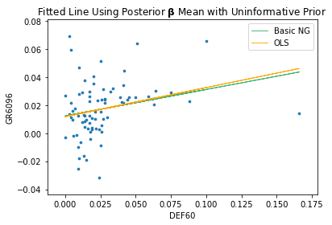

```python
plt.scatter(X[:,1], y, s=7)
plt.plot(X[:,1], X.dot(Beta_hat), color='mediumseagreen', linewidth=.9, label='Basic NG')
plt.plot(X[:,1], X.dot(np.linalg.inv((X.T).dot(X)).dot(X.T).dot(y)), color='orange', linewidth=.9, label='OLS')
plt.legend(loc='best')
plt.title(r"Fitted Line Using Posterior $\mathbf{\beta}$ Mean with Uninformative Prior")
plt.xlabel("DEF60")
plt.ylabel("GR6096")
```

### A Heavy-Tailed Error Model

#### Part (C)

We have the posterior conditional distributions specified in notes, thus we go straight to code up the Gibbs Sampler:

```python
# # raw-code version
# # Initialize hyperparameters
# p = X.shape[1]
# m, K, d, eta, h, iteration, seed = np.array([.1,.1]).T, np.diag([.1]*X.shape[1]), 1., 1., 1., 1000, 2019
# # Sample Lambda, omega and beta from their posterior conditional distributions respectively: for Gibbs Sampling,
# # all parameters depend on each other, thus we need to start with some parameter having some value already -- I
# # pick Lambda to start as identity matrix, for convenience purpose
# np.random.seed(seed=seed) # check if we wrote this line, do we still need to write random_state=seed in .rvs()
# omega_post, beta_post, Lambda_post = np.zeros((iteration,)), np.zeros((iteration,X.shape[1])), np.zeros((iteration,X.shape[0],X.shape[0]))
# for i in range(iteration):
#     # We sample omega and beta using the same function, since their posterior parameters share some non-trivial
#     # terms -- we can save ourselves from writing repetitive code by doing this.
#     omega_post[i], beta_post[i] = sample_omega_and_beta(X=X, Lambda=np.identity(X.shape[0]), d=d, eta=eta, K=K, y=y, m=m) if i==0 \
#                             else sample_omega_and_beta(X=X, Lambda=Lambda_post[i-1], d=d, eta=eta, K=K, y=y, m=m)
#     Lambda_post[i] = np.diag([*map(lambda j: sample_Lambda_j(X_j=X[j,:], y_j=y[j,0], \
#                 h=h, omega_post=omega_post[i], beta_post=beta_post[i]), np.arange(X.shape[0]))])
```

```python
def sample_omega_and_beta(X, Lambda, d, eta, K, y, m):
    U = (X.T).dot(Lambda).dot(X)+K
    V = (y.T).dot(Lambda).dot(X)+(m.T).dot(K)
    post_omega_a = (X.shape[0]+d)/2.
    q = (y.T).dot(Lambda).dot(y)+(m.T).dot(K).dot(m)-V.dot(np.linalg.inv(U)).dot(V.T)
    post_omega_b = (eta+q)/2.
    omega_post = sps.gamma.rvs(a=post_omega_a, scale=1./post_omega_b, size=1)[0]
    post_beta_mean = np.linalg.inv(U).dot(V.T)
    post_beta_cov = np.linalg.inv(omega_post*U)
    beta_post = sps.multivariate_normal.rvs(mean=post_beta_mean.flatten(), cov=post_beta_cov, size=1)
    # note that beta_post is a (p,)-shaped 1d array -- need to be cautious when calculating Lambda_i's parameter
    return omega_post, beta_post

def sample_Lambda_j(X_j, y_j, h, omega_post, beta_post):
    post_Lambdaj_a = (h+1)/2.
    post_Lambdaj_b = (omega_post*np.power(y_j-X_j.dot(beta_post.T),2)+h)/2.
    Lambdaj_post = sps.gamma.rvs(a=post_Lambdaj_a, scale=1./post_Lambdaj_b, size=1)[0]
    return Lambdaj_post

def gibbs_sampler_heavy_tailed(X, y, m, K, d, eta, h, iteration, burn_in, thinning, seed):
    # Sample Lambda, omega and beta from their posterior conditional distributions respectively: for Gibbs Sampling,
    # all parameters depend on each other, thus we need to start with some parameter having some value already -- I
    # pick Lambda to start as identity matrix, for convenience purpose
    np.random.seed(seed=seed) # check if we wrote this line, do we still need to write random_state=seed in .rvs()
    omega_post, beta_post, Lambda_post = np.zeros((iteration,)), np.zeros((iteration,X.shape[1])), np.zeros((iteration,X.shape[0],X.shape[0]))
    for i in range(iteration):
        # We sample omega and beta using the same function, since their posterior parameters share some non-trivial
        # terms -- we can save ourselves from writing repetitive code by doing this.
        omega_post[i], beta_post[i] = sample_omega_and_beta(X=X, Lambda=np.identity(X.shape[0]), d=d, eta=eta, K=K, y=y, m=m) if i==0 \
                            else sample_omega_and_beta(X=X, Lambda=Lambda_post[i-1], d=d, eta=eta, K=K, y=y, m=m)
        Lambda_post[i] = np.diag([*map(lambda j: sample_Lambda_j(X_j=X[j,:], y_j=y[j,0], \
                    h=h, omega_post=omega_post[i], beta_post=beta_post[i]), np.arange(X.shape[0]))])
    return omega_post[burn_in:][0::thinning], beta_post[burn_in:][0::thinning], Lambda_post[burn_in:][0::thinning]

def make_plot_posterior_fitted_line(X, y, heavy_tailed_gibbs_beta, basic_beta):
    plt.scatter(X[:,1], y, s=7)
    plt.plot(X[:,1], X.dot(heavy_tailed_gibbs_beta), color='r', linewidth=.9, label='Heavy-Tailed NG')
    plt.plot(X[:,1], X.dot(basic_beta), color='mediumseagreen', linewidth=.9, label='Basic NG')
    plt.plot(X[:,1], X.dot(np.linalg.inv((X.T).dot(X)).dot(X.T).dot(y)), color='orange', linewidth=.9, label='OLS')
    plt.legend(loc='best')
    plt.title(r"Fitted Lines Using Posterior $\mathbf{\beta}$ Mean with Uninformative Prior")
    plt.xlabel("DEF60")
    plt.ylabel("GR6096")
```

I got drastically different results from setting the hyperparameters differently:

```
20.49363372127575 [0.01344076 0.1134165 ]
```

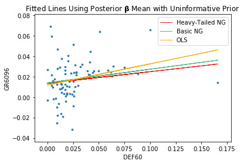

```python
hyperparam_m, hyperparam_K = np.array([[.1, .1]]), np.diag([.1, .1])
omega_post, beta_post, Lambda_post = gibbs_sampler_heavy_tailed(X=X, y=y, \
                                        m=hyperparam_m.T, K=hyperparam_K, d=4., eta=4., h=4., \
                                        burn_in=2000, thinning=3, iteration=5000, seed=2019)
print(np.mean(omega_post), np.mean(beta_post,axis=0))
Beta_hat = basic_normal_gamma(X=X, y=y, m=hyperparam_m.T, K=hyperparam_K)
make_plot_posterior_fitted_line(X=X, y=y, heavy_tailed_gibbs_beta=np.mean(beta_post,axis=0), basic_beta=Beta_hat)
```

```
20.235765470512728 [0.00677151 0.40191542]
```

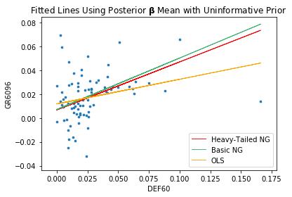

```python
hyperparam_m, hyperparam_K = np.array([[.5, .5]]), np.diag([.2, .2])
omega_post, beta_post, Lambda_post = gibbs_sampler_heavy_tailed(X=X, y=y, \
                                        m=hyperparam_m.T, K=hyperparam_K, d=4., eta=4., h=4., \
                                        burn_in=2000, thinning=3, iteration=5000, seed=2019)
print(np.mean(omega_post), np.mean(beta_post,axis=0))
Beta_hat = basic_normal_gamma(X=X, y=y, m=hyperparam_m.T, K=hyperparam_K)
make_plot_posterior_fitted_line(X=X, y=y, heavy_tailed_gibbs_beta=np.mean(beta_post,axis=0), basic_beta=Beta_hat)
```

```
20.169259954433763 [0.0028745  0.53369535]
```

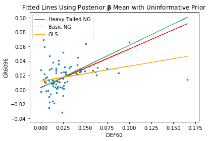

```python
hyperparam_m, hyperparam_K = np.array([[1., 1.]]), np.diag([.05, .05])
omega_post, beta_post, Lambda_post = gibbs_sampler_heavy_tailed(X=X, y=y, \
                                        m=hyperparam_m.T, K=hyperparam_K, d=4., eta=4., h=4., \
                                        burn_in=2000, thinning=3, iteration=5000, seed=2019)
print(np.mean(omega_post), np.mean(beta_post,axis=0))
Beta_hat = basic_normal_gamma(X=X, y=y, m=hyperparam_m.T, K=hyperparam_K)
make_plot_posterior_fitted_line(X=X, y=y, heavy_tailed_gibbs_beta=np.mean(beta_post,axis=0), basic_beta=Beta_hat)
```

```
19.537814929069427 [-0.00620965  0.88867112]
```

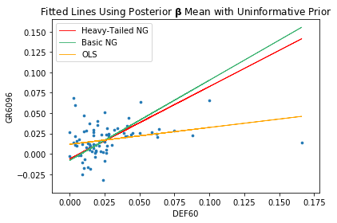

```python
hyperparam_m, hyperparam_K = np.array([[.1, 5.]]), np.diag([.5, .01])
omega_post, beta_post, Lambda_post = gibbs_sampler_heavy_tailed(X=X, y=y, \
                                        m=hyperparam_m.T, K=hyperparam_K, d=4., eta=4., h=4., \
                                        burn_in=2000, thinning=3, iteration=5000, seed=2019)
print(np.mean(omega_post), np.mean(beta_post,axis=0))
Beta_hat = basic_normal_gamma(X=X, y=y, m=hyperparam_m.T, K=hyperparam_K)
make_plot_posterior_fitted_line(X=X, y=y, heavy_tailed_gibbs_beta=np.mean(beta_post,axis=0), basic_beta=Beta_hat)
```

```
42.685196504763844 [-0.00134849  0.72052501]
```

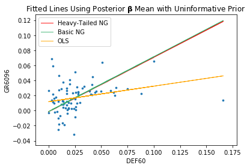

```python
hyperparam_m, hyperparam_K = np.array([[.5, 1.]]), np.diag([.1, .1])
omega_post, beta_post, Lambda_post = gibbs_sampler_heavy_tailed(X=X, y=y, \
                                        m=hyperparam_m.T, K=hyperparam_K, d=10., eta=2., h=4., \
                                        burn_in=1000, thinning=2, iteration=3000, seed=2019)
print(np.mean(omega_post), np.mean(beta_post,axis=0))
Beta_hat = basic_normal_gamma(X=X, y=y, m=hyperparam_m.T, K=hyperparam_K)
make_plot_posterior_fitted_line(X=X, y=y, heavy_tailed_gibbs_beta=np.mean(beta_post,axis=0), basic_beta=Beta_hat)
```

```
20.63854692821548 [0.0106661  0.28089819]
```

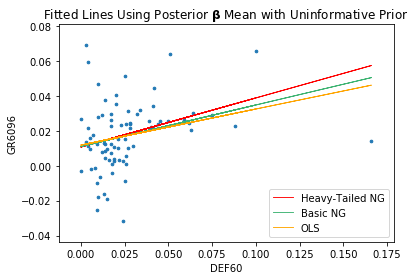

```python
hyperparam_m, hyperparam_K = np.array([[.4, .4]]), np.diag([.01, .01])
omega_post, beta_post, Lambda_post = gibbs_sampler_heavy_tailed(X=X, y=y, \
                                        m=hyperparam_m.T, K=hyperparam_K, d=4., eta=4., h=10, \
                                        burn_in=0, thinning=2, iteration=2000, seed=2019)
print(np.mean(omega_post), np.mean(beta_post,axis=0))
Beta_hat = basic_normal_gamma(X=X, y=y, m=hyperparam_m.T, K=hyperparam_K)
make_plot_posterior_fitted_line(X=X, y=y, heavy_tailed_gibbs_beta=np.mean(beta_post,axis=0), basic_beta=Beta_hat)
```

```
20.73751463448962 [0.00939821 0.27047342]
```

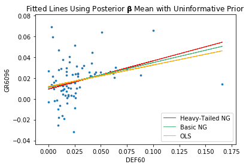

```python
hyperparam_m, hyperparam_K = np.array([[.4, .4]]), np.diag([.01, .01])
omega_post, beta_post, Lambda_post = gibbs_sampler_heavy_tailed(X=X, y=y, \
                                        m=hyperparam_m.T, K=hyperparam_K, d=4., eta=4., h=10, \
                                        burn_in=1000, thinning=2, iteration=3000, seed=2019)
print(np.mean(omega_post), np.mean(beta_post,axis=0))
Beta_hat = basic_normal_gamma(X=X, y=y, m=hyperparam_m.T, K=hyperparam_K)
make_plot_posterior_fitted_line(X=X, y=y, heavy_tailed_gibbs_beta=np.mean(beta_post,axis=0), basic_beta=Beta_hat)
```

```
1184.1271417265896 [0.00843949 0.30176747]
```

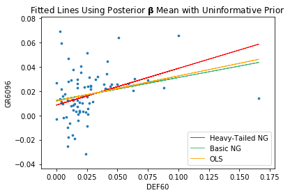

```python
hyperparam_m, hyperparam_K = np.array([[.1, .1]]), np.diag([.01, .01])
omega_post, beta_post, Lambda_post = gibbs_sampler_heavy_tailed(X=X, y=y, \
                                        m=hyperparam_m.T, K=hyperparam_K, d=.02, eta=.02, h=.02, \
                                        burn_in=1000, thinning=2, iteration=3000, seed=2019)
print(np.mean(omega_post), np.mean(beta_post,axis=0))
Beta_hat = basic_normal_gamma(X=X, y=y, m=hyperparam_m.T, K=hyperparam_K)
make_plot_posterior_fitted_line(X=X, y=y, heavy_tailed_gibbs_beta=np.mean(beta_post,axis=0), basic_beta=Beta_hat)
```

```
1723.9231019177516 [0.00839377 0.30660034]
```

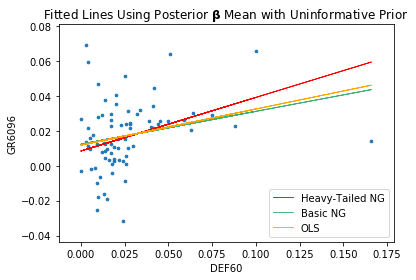

```python
hyperparam_m, hyperparam_K = np.array([[.1, .1]]), np.diag([.01, .01])
omega_post, beta_post, Lambda_post = gibbs_sampler_heavy_tailed(X=X, y=y, \
                                        m=hyperparam_m.T, K=hyperparam_K, d=.01, eta=.01, h=.01, \
                                        burn_in=2000, thinning=3, iteration=5000, seed=2019)
print(np.mean(omega_post), np.mean(beta_post,axis=0))
Beta_hat = basic_normal_gamma(X=X, y=y, m=hyperparam_m.T, K=hyperparam_K)
make_plot_posterior_fitted_line(X=X, y=y, heavy_tailed_gibbs_beta=np.mean(beta_post,axis=0), basic_beta=Beta_hat)
```

##### Initial Observation:

I initialized my hyperparameters as: $\mathbf{m}=\begin{bmatrix}0.1,0.1\end{bmatrix}^T$, $\mathbf{K}=\text{diag}(0.1,0.1)$, $d=1$, $\eta=1$, $h=1$. However, no matter after how much iteration, the fitted line varies a lot after each iteration -- my plots of iteration$=5000$, $5001$, $5002$ look sharply different from each other. Before checking my implementation, I started to suspect if it was because of my initialization, as this was what happened last time I implemented Gibbs Sampler on Abhra's class. I gradually modified $\mathbf{K}, h, d$, in which the first two didn't change much, change in $d$ seems to decrease the differences after each iteration but still didn't quite solve the problem. Finally, I modified $\mathbf{m}$ to current value, and with only $2000$ iterations I had three plot looks almost identical except the intercept location, and all look robust against the outliers.

##### Update on Above Comments:

For Gibbs Sampling, we are not just looking at the very last sample -- instead, we need to take the mean of all (burnt-in and thinned) samples to derive our posterior estimate of parameters. After we did that, the sample mean of posterior samples doesn't change much.

#### "An interesting plot will be the posterior mean of $1/\lambda_i$ for each country"

Let's try that:

```python
gdpgrowth.shape, gdpgrowth.COUNTRY.unique().shape
```

```
((79, 11), (79,))
```

Seems that each row is the data from a different country -- in other words, each $\lambda_i$ matches to a different country. We thus make the following plots -- they are matched with the last two hyperparameter settings above:

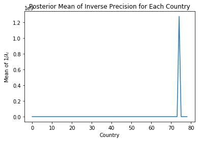

```python
posterior_mean_inverse_lambda_i = np.mean(np.array([*map(lambda i: 1/np.diagonal(Lambda_post[i]), np.arange(Lambda_post.shape[0]))]), axis=0)
plt.plot(posterior_mean_inverse_lambda_i)
#plt.ylim((0,2))
plt.xlabel('Country')
plt.ylabel(r'Mean of $1/\lambda_i$')
plt.title('Posterior Mean of Inverse Precision for Each Country')
```

```python
posterior_mean_inverse_lambda_i
```

```
array([1.98611577e+01, 3.84242325e+04, 2.10804899e+02, 1.44766083e+03,
       2.45436339e+03, 7.34649682e+00, 2.99598405e+01, 4.09904156e+03,
       2.90206579e+02, 4.07253999e+03, 7.64752957e+02, 1.35973837e+02,
       3.32161557e+02, 2.60010490e+03, 6.46328074e+01, 1.27207763e+02,
       7.21849886e+01, 2.62394263e+02, 6.23389572e+02, 3.19115496e+02,
       1.30803663e+02, 3.65747686e+02, 1.78109323e+03, 1.03582752e+02,
       2.47802113e+01, 7.91043619e+02, 3.50485762e+02, 4.59970109e+01,
       1.41348242e+05, 9.10590501e+02, 1.14232967e+01, 3.51240395e+01,
       5.37174621e+02, 3.23969790e+02, 9.35562524e+02, 6.01201665e+01,
       4.28252580e+01, 3.86764482e+02, 7.30854088e+02, 5.48275798e+01,
       2.70596537e+02, 3.28969318e+04, 1.98315669e+05, 4.64847946e+02,
       3.39101848e+02, 3.45693032e+02, 9.44115978e+01, 1.72910703e+02,
       5.11043494e+03, 8.75809941e+01, 1.76197907e+03, 1.21499404e+01,
       2.26623440e+04, 4.59853230e+02, 1.55625049e+03, 4.34958618e+04,
       7.11611420e+01, 9.89642478e+01, 2.21871313e+02, 1.37668363e+04,
       2.50867635e+01, 1.77404195e+04, 1.57052090e+03, 5.67158252e+02,
       4.62820313e+01, 4.82684894e+01, 5.46778075e+02, 2.35577626e+02,
       8.59869243e+04, 7.75103418e+01, 8.73873350e+00, 9.40135801e+01,
       2.75254713e+04, 7.72433138e+02, 1.27364360e+09, 1.44123046e+02,
       5.36573608e+01, 2.78808520e+03, 4.37608816e+01])
```

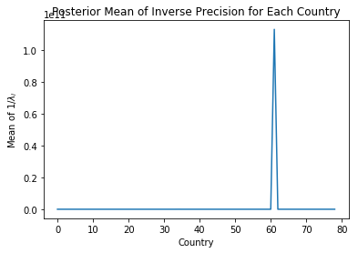

```python
posterior_mean_inverse_lambda_i = np.mean(np.array([*map(lambda i: 1/np.diagonal(Lambda_post[i]), np.arange(Lambda_post.shape[0]))]), axis=0)
plt.plot(posterior_mean_inverse_lambda_i)
#plt.ylim((0,2))
plt.xlabel('Country')
plt.ylabel(r'Mean of $1/\lambda_i$')
plt.title('Posterior Mean of Inverse Precision for Each Country')
```

```python
posterior_mean_inverse_lambda_i
```

```
array([5.53757355e+01, 1.39681591e+03, 4.42560828e+03, 5.59728189e+03,
       8.26700369e+03, 4.10918103e+02, 8.18685464e+01, 1.37365392e+02,
       1.57648064e+02, 1.20631557e+03, 5.65618203e+01, 1.27067776e+02,
       4.39648776e+02, 2.82446467e+04, 4.88511189e+02, 7.93841570e+01,
       2.39717955e+02, 1.67744381e+04, 6.05469093e+02, 3.99631014e+02,
       9.43514983e+02, 2.04540405e+01, 3.39239925e+02, 1.95329002e+02,
       1.21881724e+01, 9.81460050e+05, 3.84049589e+03, 2.28532892e+01,
       1.00204840e+02, 1.47954985e+02, 7.24647346e+01, 6.91904424e+00,
       4.66929363e+02, 1.18986952e+01, 1.07263891e+07, 1.88943388e+02,
       5.69091819e+01, 1.07033515e+04, 2.75485999e+01, 4.71515656e+01,
       1.71194772e+04, 1.52603731e+02, 2.94785339e+04, 3.26006754e+01,
       6.39951343e+01, 6.18380283e+02, 9.22502329e+00, 1.51316522e+02,
       1.27549602e+04, 5.66377306e+02, 6.34074181e+02, 8.18510037e+00,
       7.74932378e+04, 1.16072309e+04, 7.83966348e+03, 5.04252097e+03,
       3.60176666e+02, 5.96161308e+01, 6.89898322e+02, 6.89108791e+03,
       8.42105882e+01, 1.13087797e+11, 1.84568664e+04, 2.67089471e+02,
       1.96213542e+02, 3.84644979e+02, 5.37133573e+02, 2.65913493e+02,
       6.06900615e+02, 1.02135710e+02, 1.93529300e+02, 2.51175304e+02,
       4.07432559e+04, 5.53947340e+01, 1.49479412e+01, 2.20417933e+03,
       4.26832989e+01, 2.00732937e+01, 7.27059622e+01])
```

```python
np.argmax(posterior_mean_inverse_lambda_i)
```

```
61
```

```python
X[61,1], y[61,0]
```

```
(0.10000000099999999, 0.0658)
```

```python
gdpgrowth.iloc[61,:]
```

```
CODE              OAN
COUNTRY        Taiwan
GR6096         0.0658
DENS60        1.09504
COAST65        5.9724
POPGR6090    0.021919
EAST                1
DEF60             0.1
LGDP60        7.13569
EDUC60         0.0142
LIFE60           65.4
Name: 61, dtype: object
```

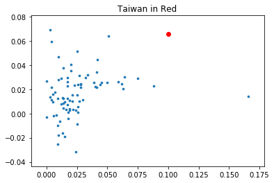

```python
plt.scatter(X[:,1], y, s=7)
plt.scatter(X[61,1], y[61,0], color='r')
plt.title("Taiwan in Red")
```

```python
posterior_mean_inverse_lambda_i[61], gdpgrowth['COUNTRY'][61]
```

```
(113087796523.7047, 'Taiwan')
```

```python
posterior_mean_inverse_lambda_i[53], gdpgrowth['COUNTRY'][53]
```

```
(11607.23093444131, 'Jordan')
```